# Final Project Analysis

Claire King

2025-05-11

# Introduction

Agronomists each have their list of important aspects of crop production. This list may include nitrogen, potassium, phosphorus, soil fertility, irrigation, growing degree days, and/or tillage practices. However, one thing does not often make their list, pollinators. Pollinators are vital in agricultural production, yet declining in population numbers.

In this study, we utilize a data set that was collected in Maine, USA to see how certain pollinators can influence the prediction of yields of wild blueberries (https://www.kaggle.com/datasets/saurabhshahane/wild-blueberry-yield-prediction/data). If pollinators are seen to significantly improve crop yields predictions, then there might be more economic incentive for major corporations to put major investment into the rehabilitation of their populations.

In this data set, four pollinators are present, honeybees, bumblebees, mining bees (andrena), and mason bees (osmia). Each is described in the following way: honeybees are the most widely known pollinator, bumblebees are known to be very strong pollinators, mining bees are important for early-blooming plants and are ground-nesting, and mason bees are known to be great pollinators of fruit trees and crops. As we dive deeper into this data, it is important to keep these relationships in mind to see if they are reflected in our analysis.

With this data, we hope to evaluate the predictive ability of these pollinators on wild blueberry yields.

# Methods

## Data Exploration

```r
## Loading data and cleaning
# Load in data & summarize
blueberry_raw <- read.csv("WildBlueberryPollinationSimulationData.csv")
head(blueberry_raw)
```

```
##   Row. clonesize honeybee bumbles andrena osmia MaxOfUpperTRange
## 1    0      37.5     0.75    0.25    0.25  0.25             86.0
## 2    1      37.5     0.75    0.25    0.25  0.25             86.0
## 3    2      37.5     0.75    0.25    0.25  0.25             94.6
## 4    3      37.5     0.75    0.25    0.25  0.25             94.6
## 5    4      37.5     0.75    0.25    0.25  0.25             86.0
## 6    5      37.5     0.75    0.25    0.25  0.25             86.0
##   MinOfUpperTRange AverageOfUpperTRange MaxOfLowerTRange MinOfLowerTRange
## 1             52.0                 71.9             62.0               30
## 2             52.0                 71.9             62.0               30
## 3             57.2                 79.0             68.2               33
## 4             57.2                 79.0             68.2               33
## 5             52.0                 71.9             62.0               30
## 6             52.0                 71.9             62.0               30
##   AverageOfLowerTRange RainingDays AverageRainingDays  fruitset fruitmass
## 1                 50.8          16               0.26 0.4106521 0.4081590
## 2                 50.8           1               0.10 0.4442544 0.4254576
## 3                 55.9          16               0.26 0.3837865 0.3991724
## 4                 55.9           1               0.10 0.4075642 0.4087893
## 5                 50.8          24               0.39 0.3544130 0.3827029
## 6                 50.8          34               0.56 0.3096695 0.3662835
##      seeds    yield
## 1 31.67890 3813.166
## 2 33.44938 4947.606
## 3 30.54631 3866.799
## 4 31.56259 4303.943
## 5 28.87371 3436.494
## 6 27.34545 2825.004
```

```r
summary(blueberry_raw)
```

```
##       Row.       clonesize        honeybee          bumbles
##  Min.   :  0   Min.   :10.00   Min.   : 0.0000   Min.   :0.0000
##  1st Qu.:194   1st Qu.:12.50   1st Qu.: 0.2500   1st Qu.:0.2500
##  Median :388   Median :12.50   Median : 0.2500   Median :0.2500
##  Mean   :388   Mean   :18.77   Mean   : 0.4171   Mean   :0.2824
##  3rd Qu.:582   3rd Qu.:25.00   3rd Qu.: 0.5000   3rd Qu.:0.3800
##  Max.   :776   Max.   :40.00   Max.   :18.4300   Max.   :0.5850
##     andrena           osmia        MaxOfUpperTRange MinOfUpperTRange
##  Min.   :0.0000   Min.   :0.0000   Min.   :69.70    Min.   :39.0
##  1st Qu.:0.3800   1st Qu.:0.5000   1st Qu.:77.40    1st Qu.:46.8
##  Median :0.5000   Median :0.6300   Median :86.00    Median :52.0
##  Mean   :0.4688   Mean   :0.5621   Mean   :82.28    Mean   :49.7
##  3rd Qu.:0.6300   3rd Qu.:0.7500   3rd Qu.:89.00    3rd Qu.:52.0
##  Max.   :0.7500   Max.   :0.7500   Max.   :94.60    Max.   :57.2
##  AverageOfUpperTRange MaxOfLowerTRange MinOfLowerTRange AverageOfLowerTRange
##  Min.   :58.20        Min.   :50.20    Min.   :24.30    Min.   :41.20
##  1st Qu.:64.70        1st Qu.:55.80    1st Qu.:27.00    1st Qu.:45.80
##  Median :71.90        Median :62.00    Median :30.00    Median :50.80
##  Mean   :68.72        Mean   :59.31    Mean   :28.69    Mean   :48.61
##  3rd Qu.:71.90        3rd Qu.:66.00    3rd Qu.:30.00    3rd Qu.:50.80
##  Max.   :79.00        Max.   :68.20    Max.   :33.00    Max.   :55.90
##   RainingDays    AverageRainingDays    fruitset        fruitmass
##  Min.   : 1.00   Min.   :0.06       Min.   :0.1927   Min.   :0.3119
##  1st Qu.: 3.77   1st Qu.:0.10       1st Qu.:0.4547   1st Qu.:0.4163
##  Median :16.00   Median :0.26       Median :0.5083   Median :0.4456
##  Mean   :18.31   Mean   :0.32       Mean   :0.5021   Mean   :0.4460
##  3rd Qu.:24.00   3rd Qu.:0.39       3rd Qu.:0.5613   3rd Qu.:0.4761
##  Max.   :34.00   Max.   :0.56       Max.   :0.6521   Max.   :0.5357
##      seeds           yield
##  Min.   :22.08   Min.   :1638
##  1st Qu.:33.12   1st Qu.:5125
##  Median :36.17   Median :6107
##  Mean   :36.12   Mean   :6013
##  3rd Qu.:39.24   3rd Qu.:7022
##  Max.   :46.59   Max.   :8969
```

```r
# First Column is not needed
blueberry_data <- blueberry_raw[ ,-1]
head(blueberry_data)
```

```
##   clonesize honeybee bumbles andrena osmia MaxOfUpperTRange MinOfUpperTRange
## 1      37.5     0.75    0.25    0.25  0.25             86.0             52.0
## 2      37.5     0.75    0.25    0.25  0.25             86.0             52.0
## 3      37.5     0.75    0.25    0.25  0.25             94.6             57.2
## 4      37.5     0.75    0.25    0.25  0.25             94.6             57.2
## 5      37.5     0.75    0.25    0.25  0.25             86.0             52.0
## 6      37.5     0.75    0.25    0.25  0.25             86.0             52.0
##   AverageOfUpperTRange MaxOfLowerTRange MinOfLowerTRange AverageOfLowerTRange
## 1                 71.9             62.0               30                 50.8
## 2                 71.9             62.0               30                 50.8
## 3                 79.0             68.2               33                 55.9
## 4                 79.0             68.2               33                 55.9
## 5                 71.9             62.0               30                 50.8
## 6                 71.9             62.0               30                 50.8
##   RainingDays AverageRainingDays  fruitset fruitmass    seeds    yield
## 1          16               0.26 0.4106521 0.4081590 31.67890 3813.166
## 2           1               0.10 0.4442544 0.4254576 33.44938 4947.606
## 3          16               0.26 0.3837865 0.3991724 30.54631 3866.799
## 4           1               0.10 0.4075642 0.4087893 31.56259 4303.943
## 5          24               0.39 0.3544130 0.3827029 28.87371 3436.494
## 6          34               0.56 0.3096695 0.3662835 27.34545 2825.004
```

```r
summary(blueberry_data)
```

```
##    clonesize        honeybee          bumbles          andrena
##  Min.   :10.00   Min.   : 0.0000   Min.   :0.0000   Min.   :0.0000
##  1st Qu.:12.50   1st Qu.: 0.2500   1st Qu.:0.2500   1st Qu.:0.3800
##  Median :12.50   Median : 0.2500   Median :0.2500   Median :0.5000
##  Mean   :18.77   Mean   : 0.4171   Mean   :0.2824   Mean   :0.4688
##  3rd Qu.:25.00   3rd Qu.: 0.5000   3rd Qu.:0.3800   3rd Qu.:0.6300
##  Max.   :40.00   Max.   :18.4300   Max.   :0.5850   Max.   :0.7500
##      osmia        MaxOfUpperTRange MinOfUpperTRange AverageOfUpperTRange
##  Min.   :0.0000   Min.   :69.70    Min.   :39.0     Min.   :58.20
##  1st Qu.:0.5000   1st Qu.:77.40    1st Qu.:46.8     1st Qu.:64.70
##  Median :0.6300   Median :86.00    Median :52.0     Median :71.90
##  Mean   :0.5621   Mean   :82.28    Mean   :49.7     Mean   :68.72
##  3rd Qu.:0.7500   3rd Qu.:89.00    3rd Qu.:52.0     3rd Qu.:71.90
##  Max.   :0.7500   Max.   :94.60    Max.   :57.2     Max.   :79.00
##  MaxOfLowerTRange MinOfLowerTRange AverageOfLowerTRange  RainingDays
##  Min.   :50.20    Min.   :24.30    Min.   :41.20        Min.   : 1.00
##  1st Qu.:55.80    1st Qu.:27.00    1st Qu.:45.80        1st Qu.: 3.77
##  Median :62.00    Median :30.00    Median :50.80        Median :16.00
##  Mean   :59.31    Mean   :28.69    Mean   :48.61        Mean   :18.31
##  3rd Qu.:66.00    3rd Qu.:30.00    3rd Qu.:50.80        3rd Qu.:24.00
##  Max.   :68.20    Max.   :33.00    Max.   :55.90        Max.   :34.00
##  AverageRainingDays    fruitset        fruitmass          seeds
##  Min.   :0.06       Min.   :0.1927   Min.   :0.3119   Min.   :22.08
##  1st Qu.:0.10       1st Qu.:0.4547   1st Qu.:0.4163   1st Qu.:33.12
##  Median :0.26       Median :0.5083   Median :0.4456   Median :36.17
##  Mean   :0.32       Mean   :0.5021   Mean   :0.4460   Mean   :36.12
##  3rd Qu.:0.39       3rd Qu.:0.5613   3rd Qu.:0.4761   3rd Qu.:39.24
##  Max.   :0.56       Max.   :0.6521   Max.   :0.5357   Max.   :46.59
##      yield
##  Min.   :1638
##  1st Qu.:5125
##  Median :6107
##  Mean   :6013
##  3rd Qu.:7022
##  Max.   :8969
```

```r
str(blueberry_data)
```

```
## 'data.frame':    777 obs. of  17 variables:
##  $ clonesize           : num  37.5 37.5 37.5 37.5 37.5 37.5 37.5 37.5 37.5 37.5 ...
##  $ honeybee            : num  0.75 0.75 0.75 0.75 0.75 0.75 0.75 0.75 0.75 0.75 ...
##  $ bumbles             : num  0.25 0.25 0.25 0.25 0.25 0.25 0.25 0.25 0.25 0.25 ...
##  $ andrena             : num  0.25 0.25 0.25 0.25 0.25 0.25 0.25 0.25 0.25 0.25 ...
##  $ osmia               : num  0.25 0.25 0.25 0.25 0.25 0.25 0.25 0.25 0.25 0.25 ...
##  $ MaxOfUpperTRange    : num  86 86 94.6 94.6 86 86 94.6 94.6 77.4 77.4 ...
##  $ MinOfUpperTRange    : num  52 52 57.2 57.2 52 52 57.2 57.2 46.8 46.8 ...
##  $ AverageOfUpperTRange: num  71.9 71.9 79 79 71.9 71.9 79 79 64.7 64.7 ...
##  $ MaxOfLowerTRange    : num  62 62 68.2 68.2 62 62 68.2 68.2 55.8 55.8 ...
##  $ MinOfLowerTRange    : num  30 30 33 33 30 30 33 33 27 27 ...
##  $ AverageOfLowerTRange: num  50.8 50.8 55.9 55.9 50.8 50.8 55.9 55.9 45.8 45.8 ...
##  $ RainingDays         : num  16 1 16 1 24 34 24 34 16 1 ...
##  $ AverageRainingDays  : num  0.26 0.1 0.26 0.1 0.39 0.56 0.39 0.56 0.26 0.1 ...
##  $ fruitset            : num  0.411 0.444 0.384 0.408 0.354 ...
##  $ fruitmass           : num  0.408 0.425 0.399 0.409 0.383 ...
##  $ seeds               : num  31.7 33.4 30.5 31.6 28.9 ...
##  $ yield               : num  3813 4948 3867 4304 3436 ...
```

As we can see from the summary table above, all covariates are numerical variables. However, it is important to notice that some predictors seem to be related to one another, such as MaxOfUpperTRange and MinOfUpperTRange. This might pose issues in our further analysis.

Now that we have a general understanding of the format of our data, we must explore the distributions and correlations between the predictors themselves.

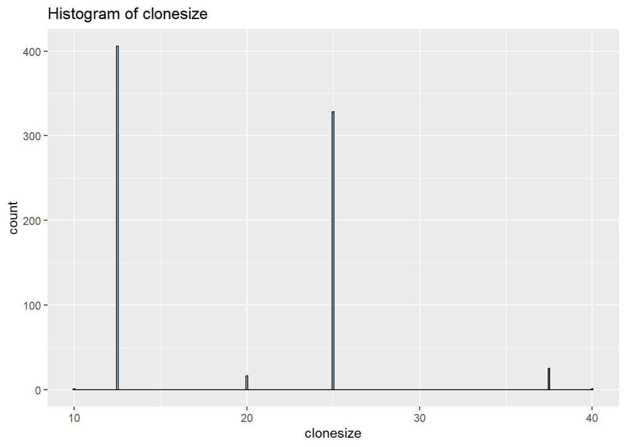

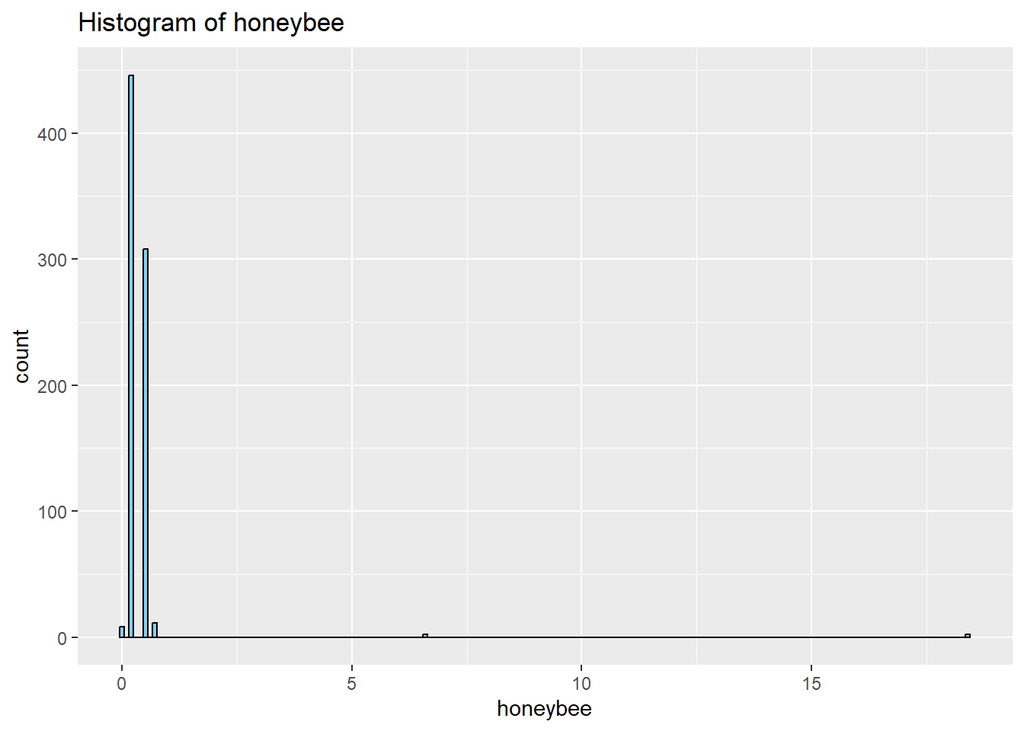

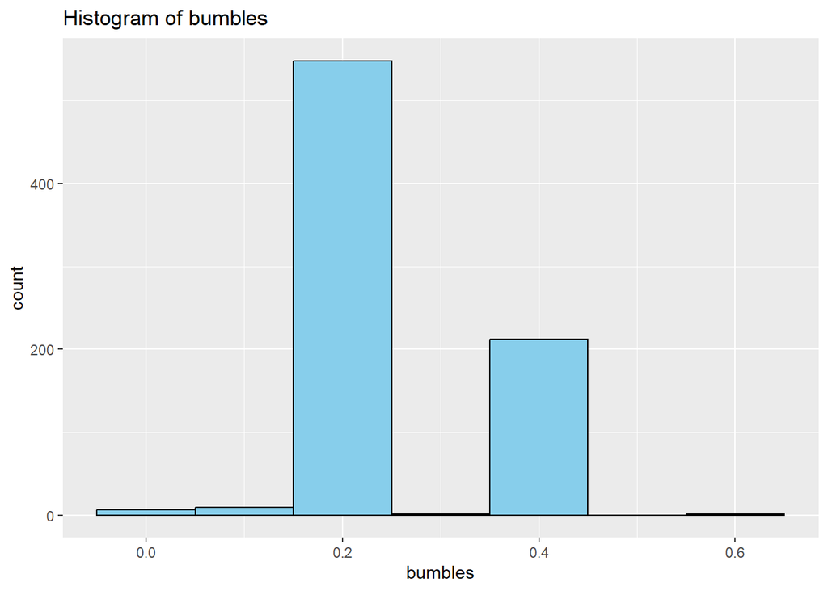

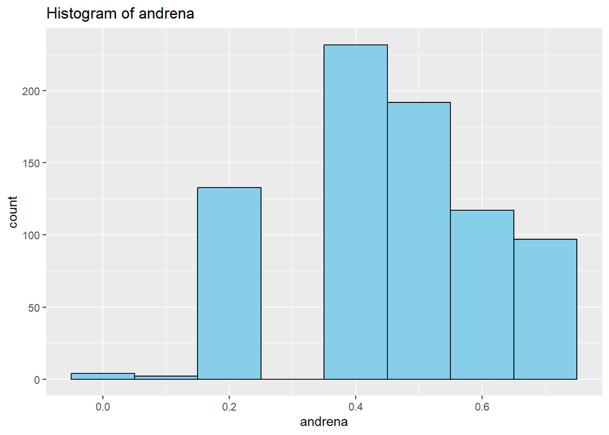

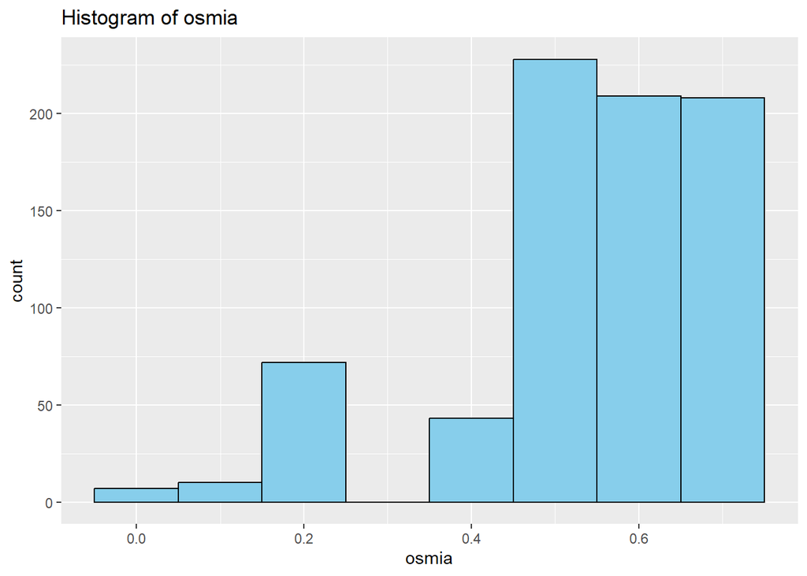

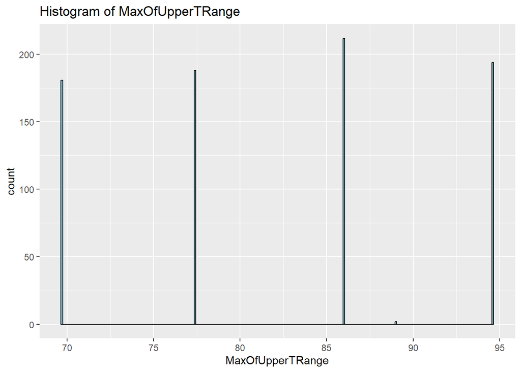

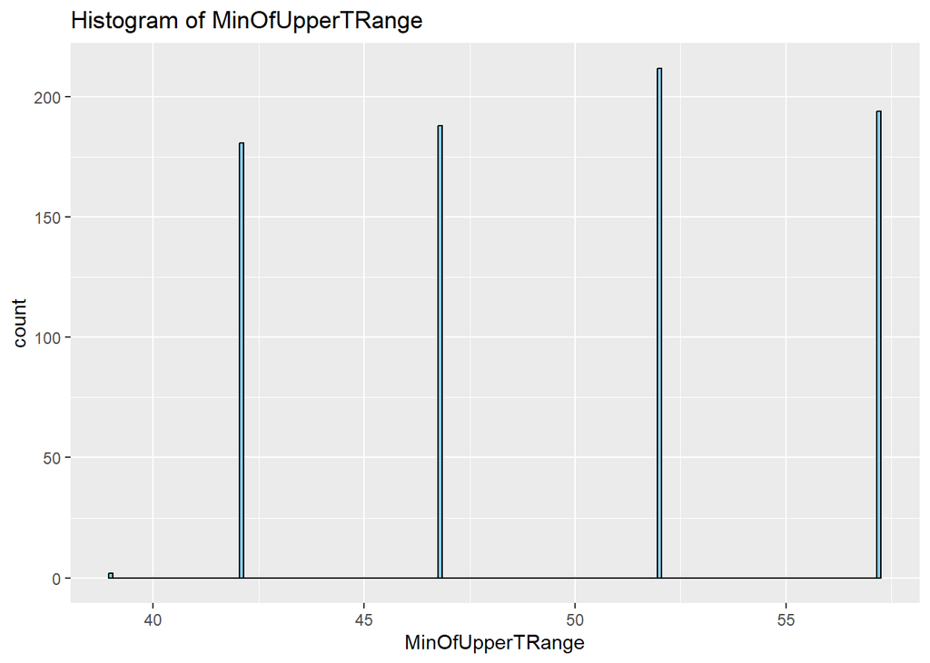

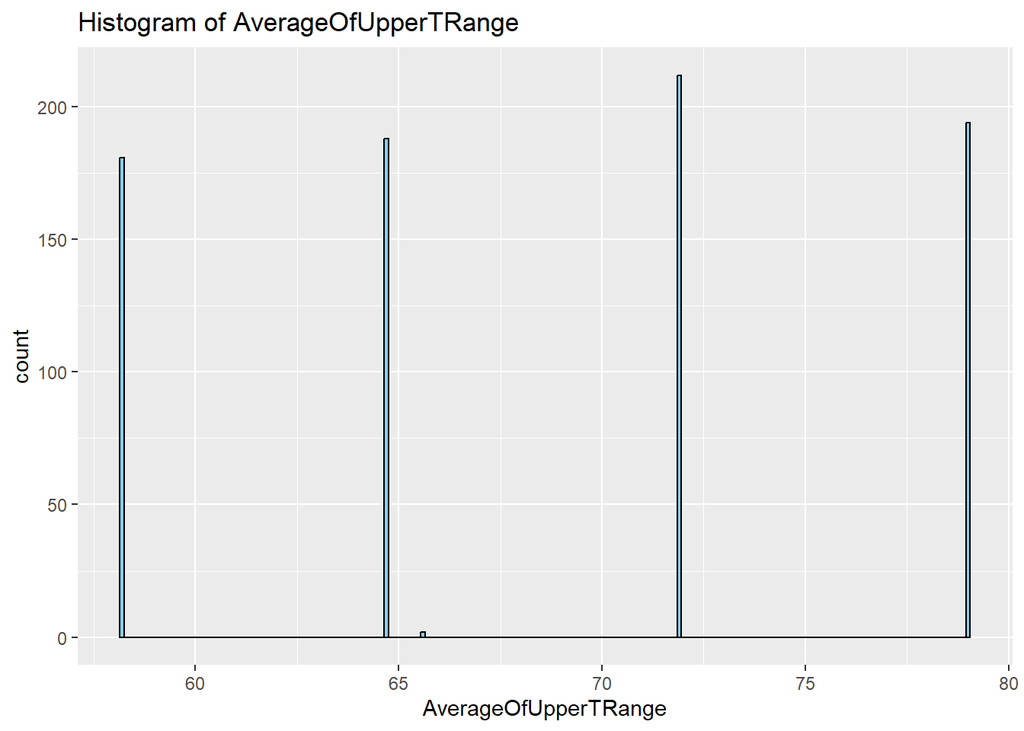

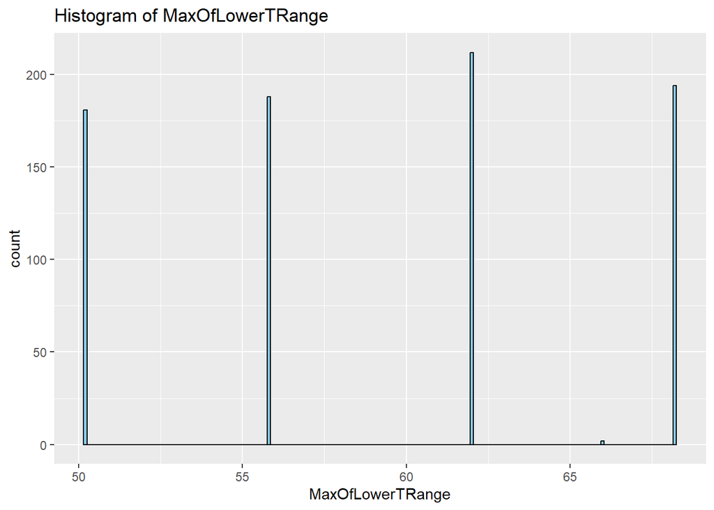

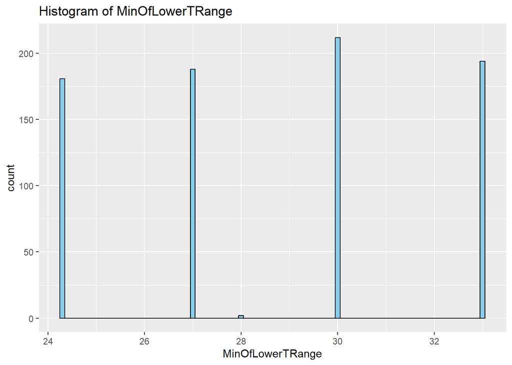

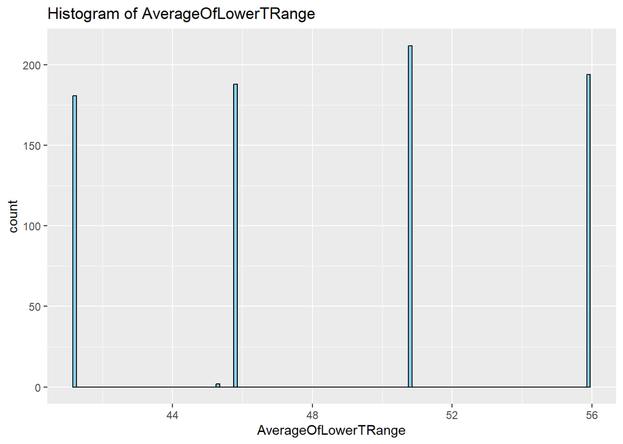

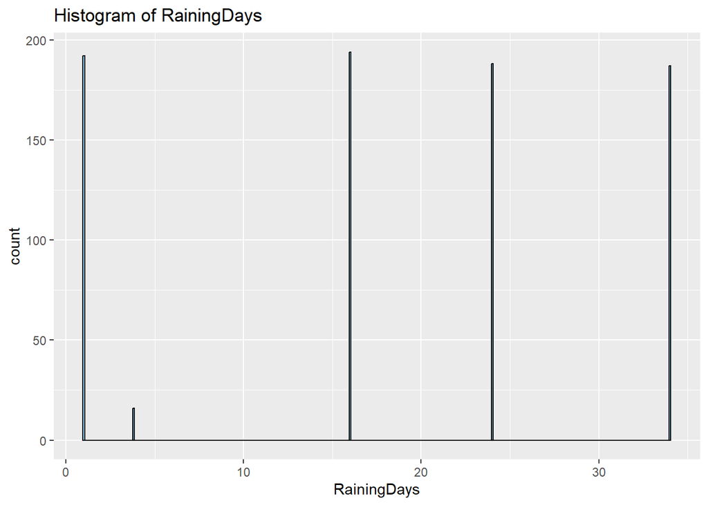

[5 more figures not shown]

```r
## Exploratory Data Analysis

# Visualize each predictor to check for outliers through using histograms
for (colname in names(blueberry_data)) {
  if (is.numeric(blueberry_data[[colname]])) {
    p <- ggplot(blueberry_data, aes_string(x = colname)) +
      geom_histogram(binwidth = 0.1, fill = "skyblue", color = "black") +
      ggtitle(paste("Histogram of", colname))
    print(p)
  }
} # -> edit these to match the needs of each histogram
```

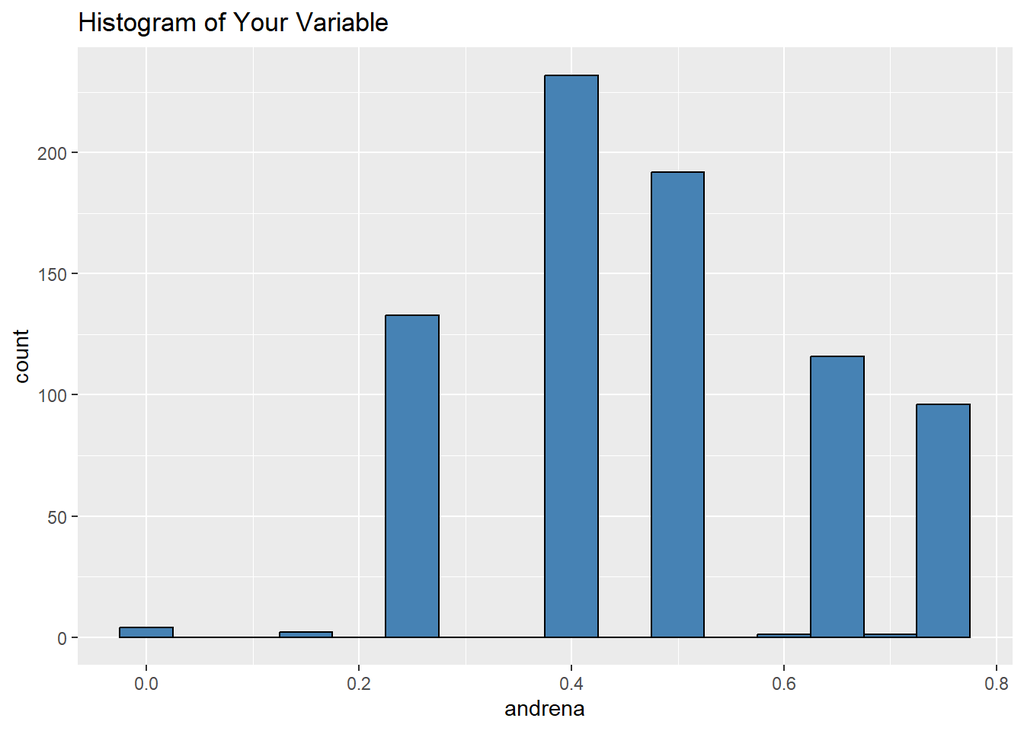

```r
ggplot(blueberry_data, aes(x = andrena)) +
  geom_histogram(binwidth = 0.05, fill = "steelblue", color = "black") +
  ggtitle("Histogram of Your Variable")
```

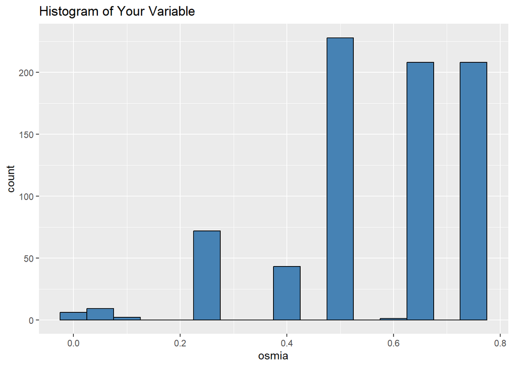

```r
ggplot(blueberry_data, aes(x = osmia)) +
  geom_histogram(binwidth = 0.05, fill = "steelblue", color = "black") +
  ggtitle("Histogram of Your Variable")
```

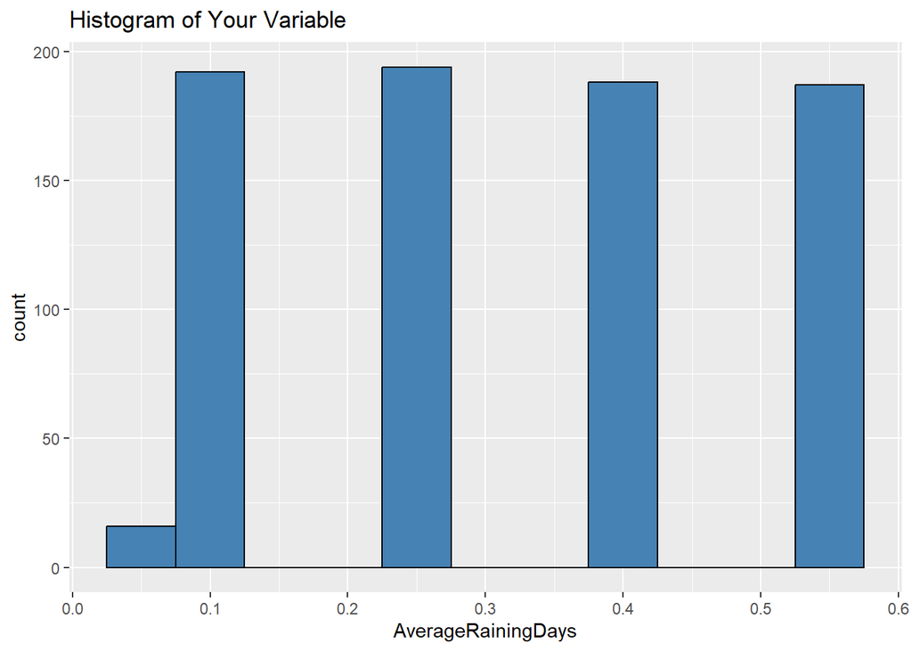

```r
ggplot(blueberry_data, aes(x = AverageRainingDays)) +
  geom_histogram(binwidth = 0.05, fill = "steelblue", color = "black") +
  ggtitle("Histogram of Your Variable")
```

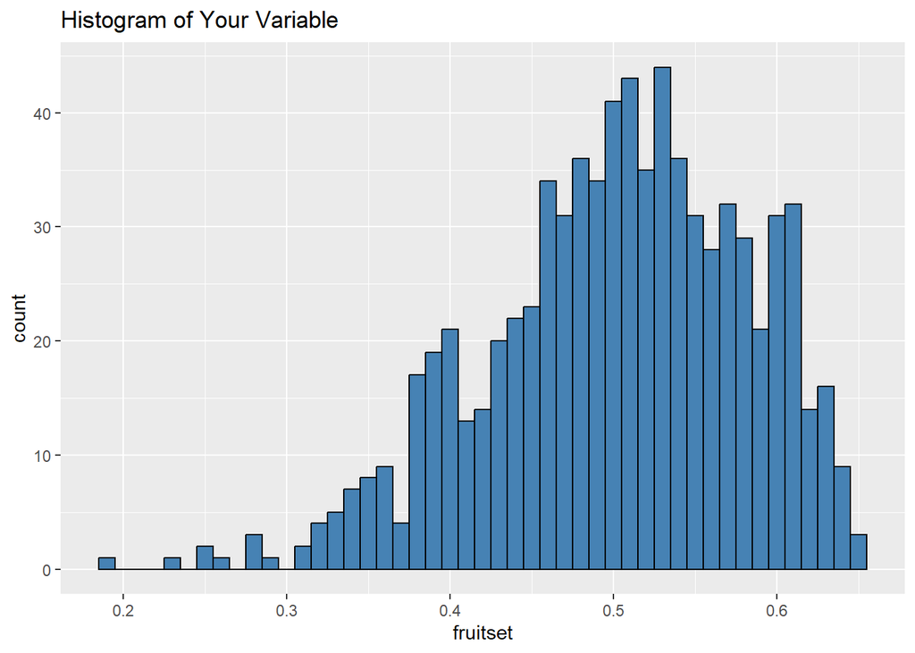

```r
ggplot(blueberry_data, aes(x = fruitset)) +
  geom_histogram(binwidth = 0.01, fill = "steelblue", color = "black") +
  ggtitle("Histogram of Your Variable")
```

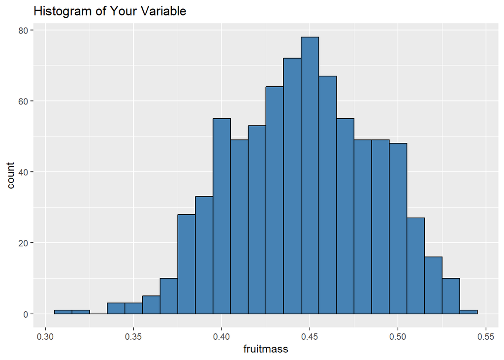

```r
ggplot(blueberry_data, aes(x = fruitmass)) +
  geom_histogram(binwidth = 0.01, fill = "steelblue", color = "black") +
  ggtitle("Histogram of Your Variable")
```

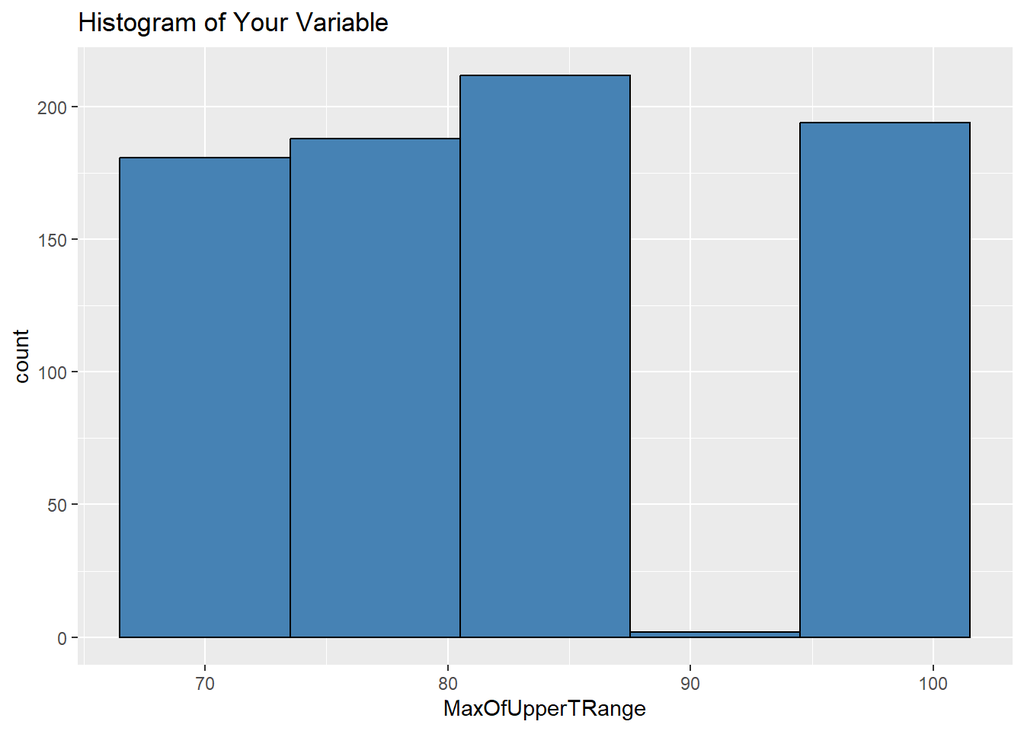

```r
ggplot(blueberry_data, aes(x = MaxOfUpperTRange)) +
  geom_histogram(binwidth = 7, fill = "steelblue", color = "black") +
  ggtitle("Histogram of Your Variable")
```

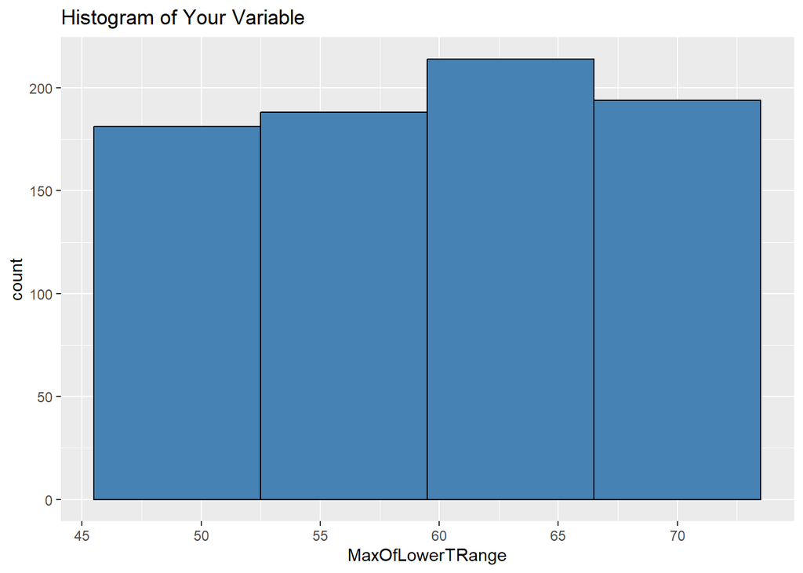

```r
ggplot(blueberry_data, aes(x = MaxOfLowerTRange)) +
  geom_histogram(binwidth = 7, fill = "steelblue", color = "black") +
  ggtitle("Histogram of Your Variable")
```

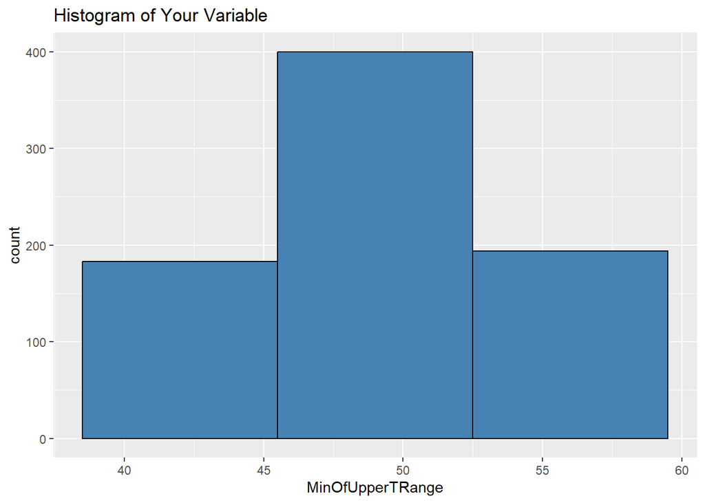

```r
ggplot(blueberry_data, aes(x = MinOfUpperTRange)) +
  geom_histogram(binwidth = 7, fill = "steelblue", color = "black") +
  ggtitle("Histogram of Your Variable")
```

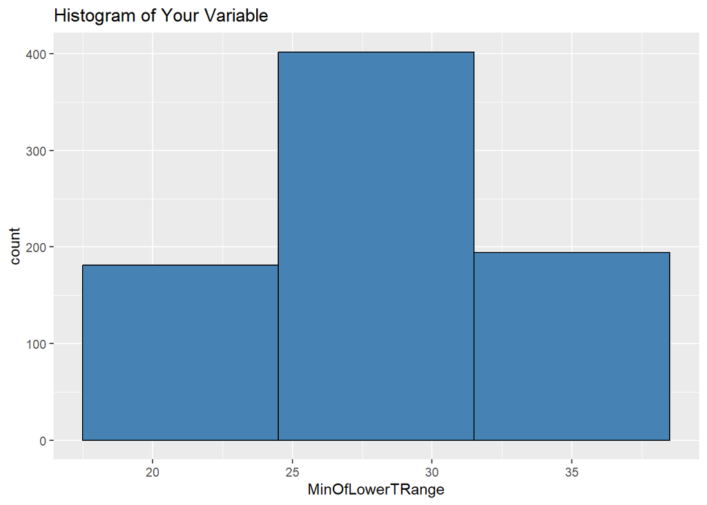

```r
ggplot(blueberry_data, aes(x = MinOfLowerTRange)) +
  geom_histogram(binwidth = 7, fill = "steelblue", color = "black") +
  ggtitle("Histogram of Your Variable")
```

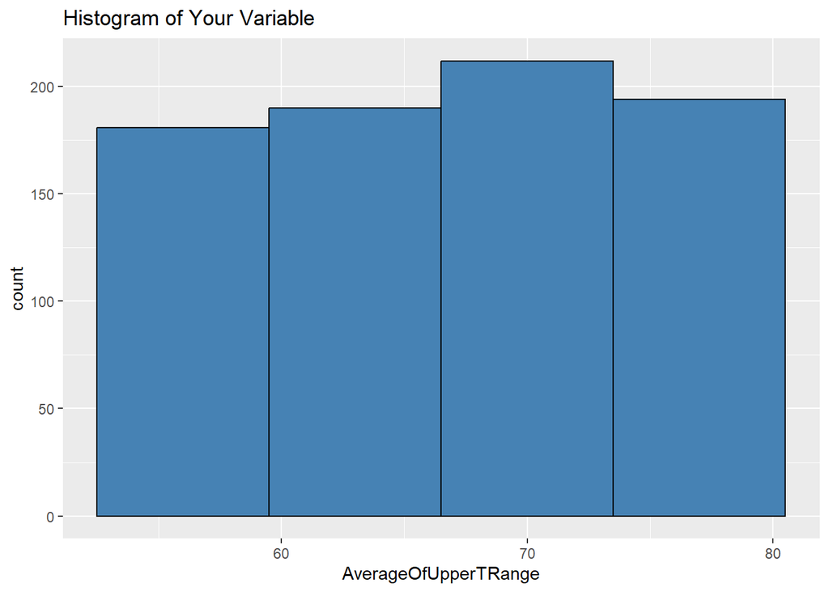

```r
ggplot(blueberry_data, aes(x = AverageOfUpperTRange)) +
  geom_histogram(binwidth = 7, fill = "steelblue", color = "black") +
  ggtitle("Histogram of Your Variable")
```

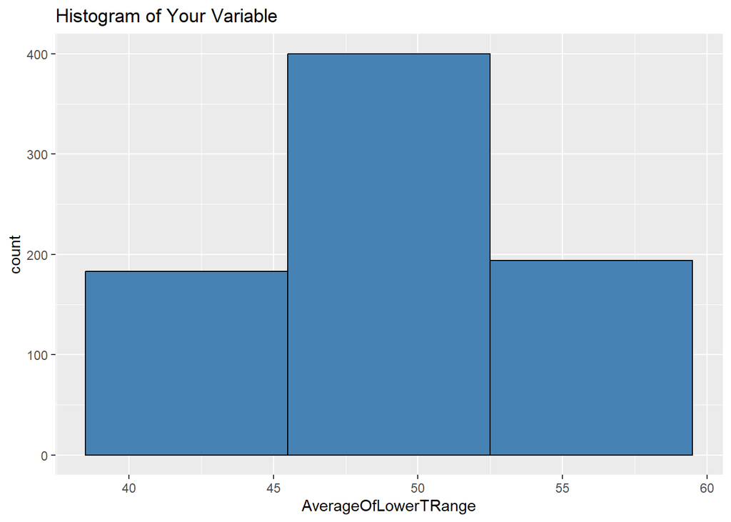

```r
ggplot(blueberry_data, aes(x = AverageOfLowerTRange)) +
  geom_histogram(binwidth = 7, fill = "steelblue", color = "black") +
  ggtitle("Histogram of Your Variable")
```

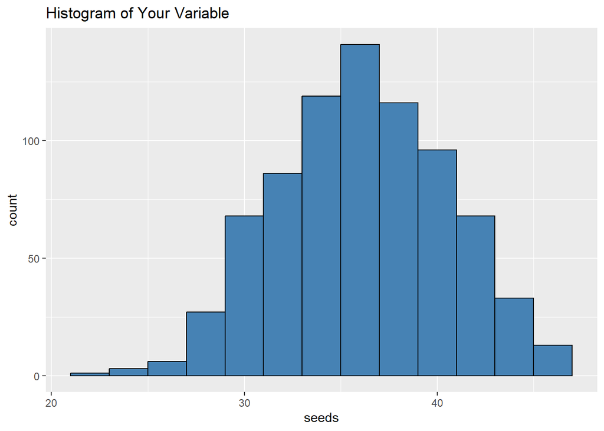

```r
ggplot(blueberry_data, aes(x = seeds)) +
  geom_histogram(binwidth = 2, fill = "steelblue", color = "black") +
  ggtitle("Histogram of Your Variable")
```

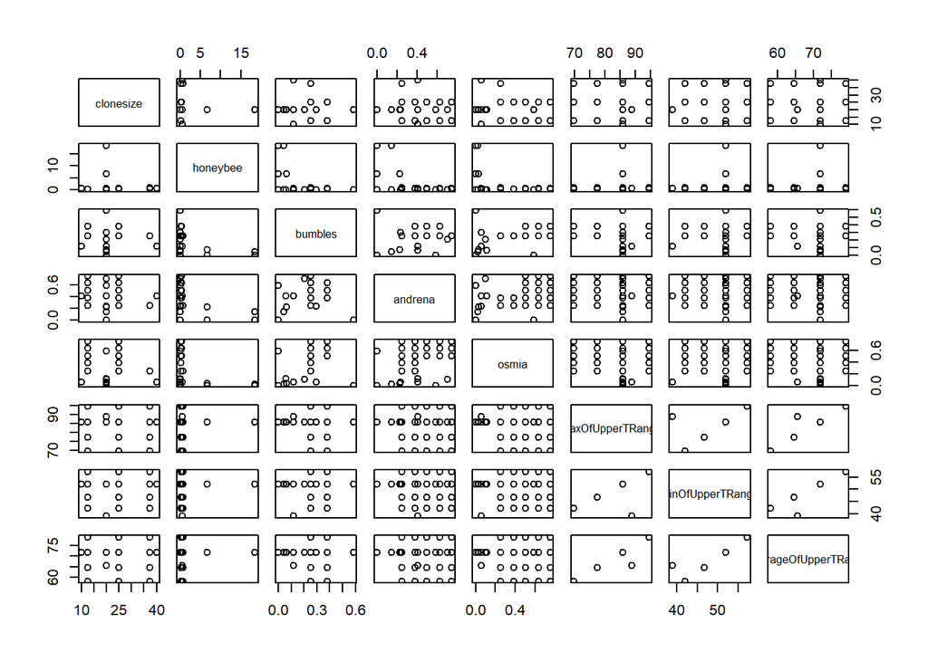

```r
# Assessing variables against one another

pairs(blueberry_data[, 1:8])
```

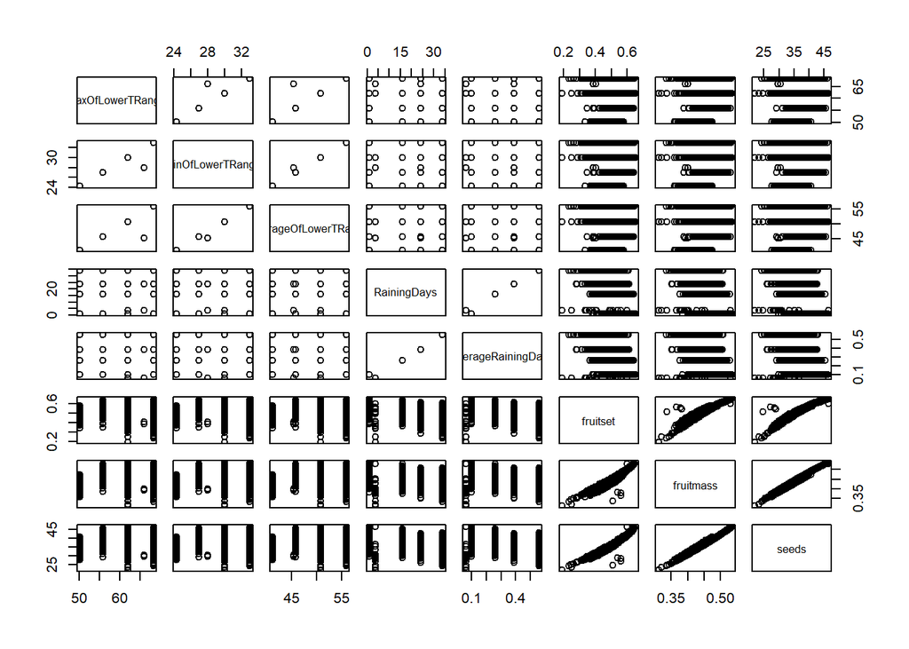

```r
pairs(blueberry_data[, 9:16])
```

To begin, we would like to visualize the distributions through histograms. However, as seen through the first for loop, we need variable bin sizes to accomplish this. Therefore, the next step of ggplot strings edits the bin size of each predictor to fit its need. From these histograms, we are mostly satisfied with the distributions that are present! We must note the presence of a few outliers in fruitset and fruitmass.

Next, we plotted all covariates against one another using the pairs() function. Most of the graphs are uninformative, besides those that are associated with fruitset, fruitmass, and seeds, which all seem to have a very strong positive correlation.

## Model Creation

Now that we have more understanding of our data, we can begin to fit our linear model.

```r
## Creating the linear model

original_mod <- lm(yield ~ clonesize + honeybee + bumbles + andrena + osmia + MaxOfUpperTRange + MinOfUpperTRange + AverageOfUpperTRange + MaxOfLowerTRange + MinOfLowerTRange + AverageOfLowerTRange + RainingDays + AverageRainingDays + fruitset + fruitmass + seeds, data = blueberry_data)
summary(original_mod)
```

```
##
## Call:
## lm(formula = yield ~ clonesize + honeybee + bumbles + andrena +
##     osmia + MaxOfUpperTRange + MinOfUpperTRange + AverageOfUpperTRange +
##     MaxOfLowerTRange + MinOfLowerTRange + AverageOfLowerTRange +
##     RainingDays + AverageRainingDays + fruitset + fruitmass +
##     seeds, data = blueberry_data)
##
## Residuals:
##     Min      1Q  Median      3Q     Max
## -520.89  -76.77   -0.43   66.94  447.99
##
## Coefficients: (2 not defined because of singularities)
##                        Estimate Std. Error t value Pr(>|t|)
## (Intercept)            1755.725    442.092   3.971 7.82e-05 ***
## clonesize                -7.831      1.239  -6.319 4.47e-10 ***
## honeybee                 50.387      8.478   5.943 4.25e-09 ***
## bumbles                 213.304    100.196   2.129 0.033586 *
## andrena                 353.839     31.228  11.331  < 2e-16 ***
## osmia                   549.788     36.124  15.219  < 2e-16 ***
## MaxOfUpperTRange      -3005.920    706.260  -4.256 2.34e-05 ***
## MinOfUpperTRange        649.257    203.187   3.195 0.001454 **
## AverageOfUpperTRange   -278.506    215.963  -1.290 0.197580
## MaxOfLowerTRange       3931.387    929.944   4.228 2.65e-05 ***
## MinOfLowerTRange             NA         NA      NA       NA
## AverageOfLowerTRange         NA         NA      NA       NA
## RainingDays              -1.471      2.938  -0.501 0.616716
## AverageRainingDays     -825.199    219.369  -3.762 0.000182 ***
## fruitset               8889.716    503.629  17.651  < 2e-16 ***
## fruitmass            -26933.172   3049.837  -8.831  < 2e-16 ***
## seeds                   351.819     24.193  14.542  < 2e-16 ***
## ---
## Signif. codes:  0 '***' 0.001 '**' 0.01 '*' 0.05 '.' 0.1 ' ' 1
##
## Residual standard error: 123.9 on 762 degrees of freedom
## Multiple R-squared:  0.9918, Adjusted R-squared:  0.9917
## F-statistic:  6590 on 14 and 762 DF,  p-value: < 2.2e-16
```

From our first linear model, as predicted, we see that two covariates were not included due to perfect colinearity. This is concerning. Therefore, the first assumption that we wanted to test was multicolinearity.

## Testing Assumptions

```r
### Regression Assumptions Verification

## Multicollinearity assessment -> model creation has already taken out two variables due to almost perfect collinearity

sec_mod <- lm(yield ~ clonesize + honeybee + bumbles + andrena + osmia + MaxOfUpperTRange + MinOfUpperTRange + AverageOfUpperTRange + MaxOfLowerTRange +   RainingDays + AverageRainingDays + fruitset + fruitmass + seeds, data = blueberry_data)
summary(sec_mod)
```

```
##
## Call:
## lm(formula = yield ~ clonesize + honeybee + bumbles + andrena +
##     osmia + MaxOfUpperTRange + MinOfUpperTRange + AverageOfUpperTRange +
##     MaxOfLowerTRange + RainingDays + AverageRainingDays + fruitset +
##     fruitmass + seeds, data = blueberry_data)
##
## Residuals:
##     Min      1Q  Median      3Q     Max
## -520.89  -76.77   -0.43   66.94  447.99
##
## Coefficients:
##                        Estimate Std. Error t value Pr(>|t|)
## (Intercept)            1755.725    442.092   3.971 7.82e-05 ***
## clonesize                -7.831      1.239  -6.319 4.47e-10 ***
## honeybee                 50.387      8.478   5.943 4.25e-09 ***
## bumbles                 213.304    100.196   2.129 0.033586 *
## andrena                 353.839     31.228  11.331  < 2e-16 ***
## osmia                   549.788     36.124  15.219  < 2e-16 ***
## MaxOfUpperTRange      -3005.920    706.260  -4.256 2.34e-05 ***
## MinOfUpperTRange        649.257    203.187   3.195 0.001454 **
## AverageOfUpperTRange   -278.506    215.963  -1.290 0.197580
## MaxOfLowerTRange       3931.387    929.944   4.228 2.65e-05 ***
## RainingDays              -1.471      2.938  -0.501 0.616716
## AverageRainingDays     -825.199    219.369  -3.762 0.000182 ***
## fruitset               8889.716    503.629  17.651  < 2e-16 ***
## fruitmass            -26933.172   3049.837  -8.831  < 2e-16 ***
## seeds                   351.819     24.193  14.542  < 2e-16 ***
## ---
## Signif. codes:  0 '***' 0.001 '**' 0.01 '*' 0.05 '.' 0.1 ' ' 1
##
## Residual standard error: 123.9 on 762 degrees of freedom
## Multiple R-squared:  0.9918, Adjusted R-squared:  0.9917
## F-statistic:  6590 on 14 and 762 DF,  p-value: < 2.2e-16
```

```r
alias(sec_mod)
```

```
## Model :
## yield ~ clonesize + honeybee + bumbles + andrena + osmia + MaxOfUpperTRange +
##     MinOfUpperTRange + AverageOfUpperTRange + MaxOfLowerTRange +
##     RainingDays + AverageRainingDays + fruitset + fruitmass +
##     seeds
```

```r
vif(sec_mod)
```

```
##            clonesize             honeybee              bumbles
##         3.800417e+00         3.479346e+00         2.232211e+00
##              andrena                osmia     MaxOfUpperTRange
##         1.277828e+00         1.885464e+00         2.129868e+06
##     MinOfUpperTRange AverageOfUpperTRange     MaxOfLowerTRange
##         6.530566e+04         1.388605e+05         1.930651e+06
##          RainingDays   AverageRainingDays             fruitset
##         6.410320e+01         7.131775e+01         8.087148e+01
##            fruitmass                seeds
##         7.643746e+02         5.667084e+02
```

We can see that there are linearly dependent covariates in the original model. Therefore, we will take only keep the AverageOfUpperTRange and AverageOfLowerTRange to keep the most information without observing colinearity.

```r
# Create new model
avg_mod <- lm(yield ~ clonesize + honeybee + bumbles + andrena + osmia +
                    AverageOfUpperTRange + AverageOfLowerTRange +
                    RainingDays + AverageRainingDays +
                    fruitset + fruitmass + seeds,
                  data = blueberry_data)


# Test collinearity again

vif(avg_mod) # Still having collinearity!
```

```
##            clonesize             honeybee              bumbles
##             3.737794             2.589203             2.145330
##              andrena                osmia AverageOfUpperTRange
##             1.273988             1.841972          7042.359547
## AverageOfLowerTRange          RainingDays   AverageRainingDays
##          7010.783405            64.075515            71.225389
##             fruitset            fruitmass                seeds
##            58.484323           204.302347           257.630517
```

```r
alias(avg_mod)
```

```
## Model :
## yield ~ clonesize + honeybee + bumbles + andrena + osmia + AverageOfUpperTRange +
##     AverageOfLowerTRange + RainingDays + AverageRainingDays +
##     fruitset + fruitmass + seeds
```

```r
cor(blueberry_data[, c("AverageOfUpperTRange", "AverageOfLowerTRange",
                  "RainingDays", "AverageRainingDays",
                  "fruitset", "fruitmass", "seeds")]) # identify correlations and clean model further
```

```
##                      AverageOfUpperTRange AverageOfLowerTRange  RainingDays
## AverageOfUpperTRange          1.000000000          0.999923355 -0.002325456
## AverageOfLowerTRange          0.999923355          1.000000000 -0.001924534
## RainingDays                  -0.002325456         -0.001924534  1.000000000
## AverageRainingDays           -0.004194561         -0.003626399  0.991394645
## fruitset                     -0.125081634         -0.124784315 -0.484228924
## fruitmass                     0.064034304          0.064180953 -0.452327709
## seeds                        -0.028924825         -0.028620812 -0.475461635
##                      AverageRainingDays   fruitset   fruitmass       seeds
## AverageOfUpperTRange       -0.004194561 -0.1250816  0.06403430 -0.02892482
## AverageOfLowerTRange       -0.003626399 -0.1247843  0.06418095 -0.02862081
## RainingDays                 0.991394645 -0.4842289 -0.45232771 -0.47546163
## AverageRainingDays          1.000000000 -0.4888092 -0.45183674 -0.47452813
## fruitset                   -0.488809221  1.0000000  0.94819314  0.96669390
## fruitmass                  -0.451836736  0.9481931  1.00000000  0.99126981
## seeds                      -0.474528133  0.9666939  0.99126981  1.00000000
```

```r
final_data <- blueberry_data[, c("clonesize", "honeybee", "bumbles", "andrena" ,"osmia",
                                 "AverageOfUpperTRange", "AverageRainingDays",
                                 "fruitmass", "yield")]

final_mod <- lm(yield ~ clonesize + honeybee + bumbles + andrena + osmia +
                    AverageOfUpperTRange + AverageRainingDays + fruitmass,
                  data = blueberry_data)
vif(final_mod) # -> yay! these all look great :)
```

```
##            clonesize             honeybee              bumbles
##             1.639709             1.107399             1.470465
##              andrena                osmia AverageOfUpperTRange
##             1.207285             1.493795             1.030809
##   AverageRainingDays            fruitmass
##             1.785257             2.893998
```

From the code chunk above, one can see that it took more refining to get to a model that did not violate the multicolinearity assumption. Additionally, keeping the average values, rather than the maximums and minimums, gives us the most information possible. Now, we can move on to checking the rest of the assumptions of linear regression.

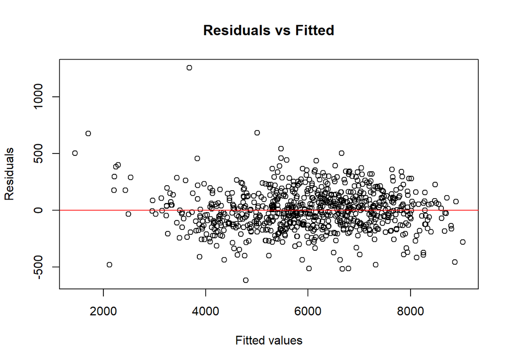

```r
### Continue on with other assumptions

## Linearity

plot(final_mod$fitted.values, resid(final_mod),
     xlab = "Fitted values", ylab = "Residuals",
     main = "Residuals vs Fitted")
abline(h = 0, col = "red")
```

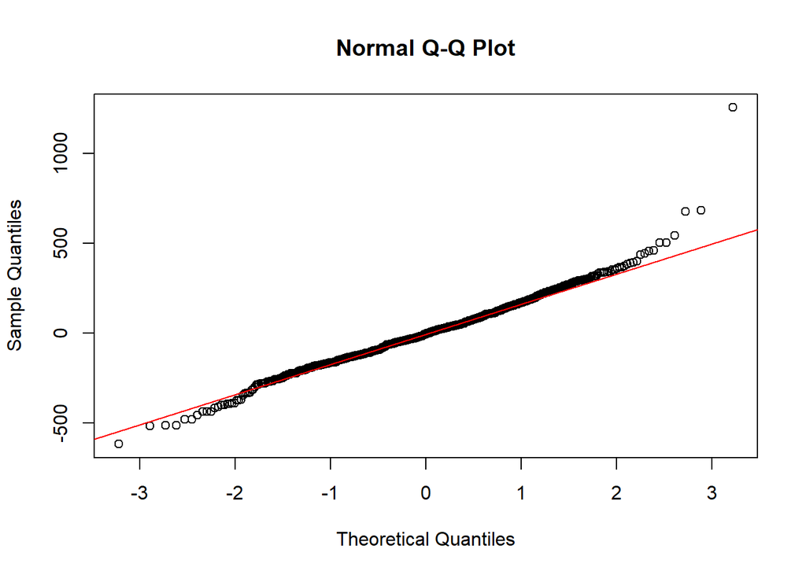

```r
## Normality of Residuals

qqnorm(resid(final_mod))
qqline(resid(final_mod), col = "red")
```

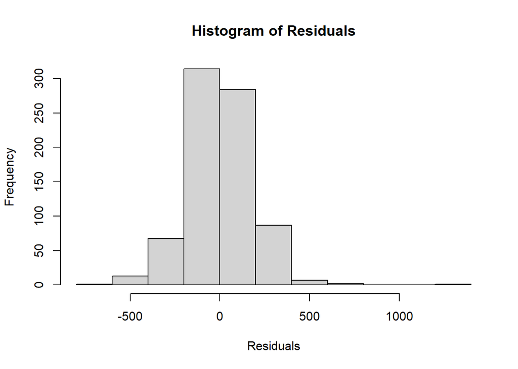

```r
hist(resid(final_mod), main = "Histogram of Residuals", xlab = "Residuals")
```

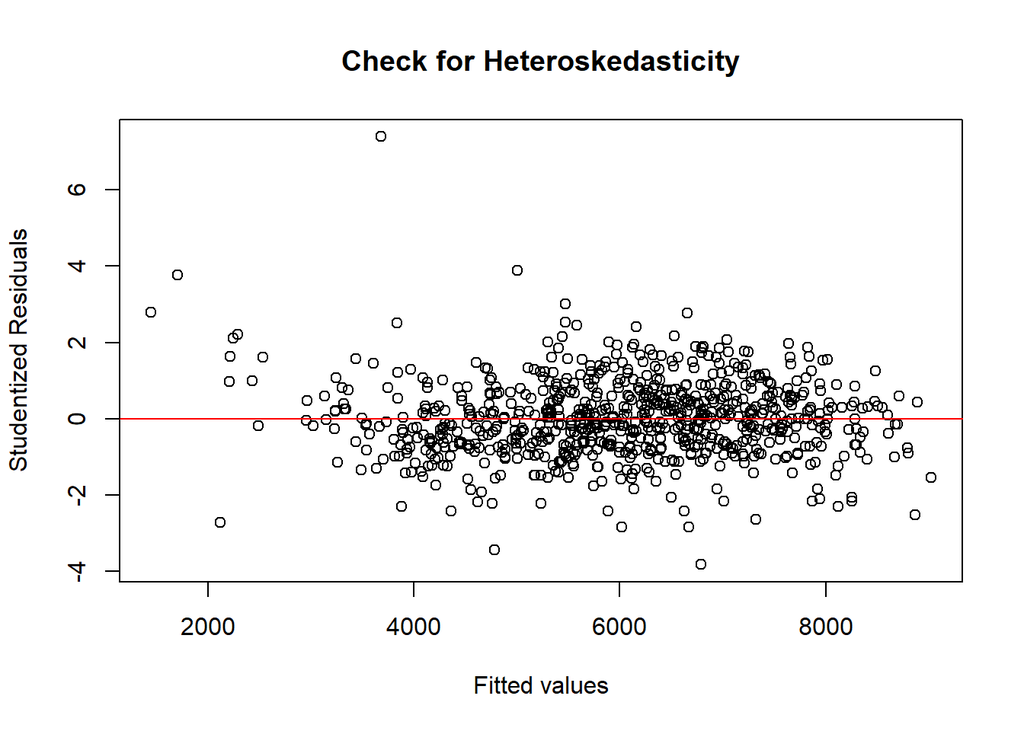

```r
## Homoscedasticity (constant variance of residuals)

plot(final_mod$fitted.values, rstudent(final_mod),
     xlab = "Fitted values", ylab = "Studentized Residuals",
     main = "Check for Heteroskedasticity")
abline(h = 0, col = "red") # -> looks ok!
```

```r
bptest <- (final_mod$res^2) / mean(final_mod$res^2)
par(mfrow = c(1,2))
plot(blueberry_data$yield, bptest, ylab = "Standardized Sq Res", xlab = "Covariate")
abline(a = lm(bptest~blueberry_data$yield)$coef[1], b = lm(bptest~blueberry_data$yield)$coef[2], col = "red") # -> Looks ok-ish

bptest(final_mod) # -> look for explanation on why this may not matter, if you wanted assumption to be absolutely satified due to wanting inference, you would need to do ....
```

```
##
##  studentized Breusch-Pagan test
##
## data:  final_mod
## BP = 113.51, df = 8, p-value < 2.2e-16
```

```r
# Heteroscedasticity observed ... Oh No! -> Correct using sandwich estimators
coeftest(final_mod, vcov = vcovHC(final_mod, type = "HC1"))
```

```
##
## t test of coefficients:
##
##                         Estimate  Std. Error  t value  Pr(>|t|)
## (Intercept)          -1882.47303   165.05104 -11.4054 < 2.2e-16 ***
## clonesize              -34.56395     1.34366 -25.7237 < 2.2e-16 ***
## honeybee               168.78335    17.52654   9.6302 < 2.2e-16 ***
## bumbles               1330.55364   126.94797  10.4811 < 2.2e-16 ***
## andrena                401.80286    44.92884   8.9431 < 2.2e-16 ***
## osmia                  933.14934    49.96533  18.6759 < 2.2e-16 ***
## AverageOfUpperTRange   -38.27399     0.83813 -45.6661 < 2.2e-16 ***
## AverageRainingDays   -1859.39517    55.33869 -33.6003 < 2.2e-16 ***
## fruitmass            23790.84528   292.61367  81.3046 < 2.2e-16 ***
## ---
## Signif. codes:  0 '***' 0.001 '**' 0.01 '*' 0.05 '.' 0.1 ' ' 1
```

```r
summary(final_mod)
```

```
##
## Call:
## lm(formula = yield ~ clonesize + honeybee + bumbles + andrena +
##     osmia + AverageOfUpperTRange + AverageRainingDays + fruitmass,
##     data = blueberry_data)
##
## Residuals:
##     Min      1Q  Median      3Q     Max
## -617.19 -119.35   -6.55  106.82 1253.42
##
## Coefficients:
##                        Estimate Std. Error t value Pr(>|t|)
## (Intercept)          -1882.4730   135.1575 -13.928   <2e-16 ***
## clonesize              -34.5640     1.1977 -28.858   <2e-16 ***
## honeybee               168.7834     7.0375  23.983   <2e-16 ***
## bumbles               1330.5536   119.6569  11.120   <2e-16 ***
## andrena                401.8029    44.6629   8.996   <2e-16 ***
## osmia                  933.1493    47.3108  19.724   <2e-16 ***
## AverageOfUpperTRange   -38.2740     0.8658 -44.208   <2e-16 ***
## AverageRainingDays   -1859.3952    51.0686 -36.410   <2e-16 ***
## fruitmass            23790.8453   276.1217  86.161   <2e-16 ***
## ---
## Signif. codes:  0 '***' 0.001 '**' 0.01 '*' 0.05 '.' 0.1 ' ' 1
##
## Residual standard error: 182.4 on 768 degrees of freedom
## Multiple R-squared:  0.9821, Adjusted R-squared:  0.9819
## F-statistic:  5275 on 8 and 768 DF,  p-value: < 2.2e-16
```

```r
## Independence of Observations
# explain about time dependence/clustering
```

[figure not shown]

Beginning with linearity, I do not see the presence of a fan shape, or any other shape, which leads me to say that this assumption is upheld

For the normality assumption, the qqplot has some slight deviation in the line, but nothing concerning. The histogram also moves me to say that the normality assumption is upheld, due to its normal distribution.

When checking the homoscedasticity assumption, there does not seem to be a lot of reason for concern from the plots. The residuals vs. fitted values plot does not have any significant shape, while the standardized squared residuals vs. the covariates only has one outlier present. However, when a Breusch-Pagan test is run, there is evidence of heteroscedasticity in the data. This is concerning, so we corrected using sandwich estimators. When using sandwich estimators, we see that standard errors are generally larger, which is expected. It is important to note how the standard errors of honeybee significantly increased, show its variability.

## Variable Selection

```r
### Variable Selection

## Try first with forward selection

intOnly <- lm(yield ~ 1, data = final_data)

mod <- lm(yield ~ ., data = final_data)
out_forward_bic <- step(object = intOnly, direction = "forward",
scope = formula(mod), trace = T, k = log(nrow(final_data)))
```

```
## Start:  AIC=11214.65
## yield ~ 1
##
##                        Df  Sum of Sq        RSS   AIC
## + fruitmass             1 1236800060  192070263  9662
## + AverageRainingDays    1  418535550 1010334773 10952
## + clonesize             1  381532339 1047337984 10980
## + osmia                 1  207298435 1221571888 11100
## + bumbles               1  136789705 1292080618 11143
## + AverageOfUpperTRange  1   47212382 1381657941 11195
## + andrena               1   28116902 1400753421 11206
## <none>                               1428870323 11215
## + honeybee              1    2797786 1426072537 11220
##
## Step:  AIC=9662.04
## yield ~ fruitmass
##
##                        Df Sum of Sq       RSS    AIC
## + AverageOfUpperTRange  1  83573562 108496701 9224.9
## + AverageRainingDays    1  26218024 165852239 9554.7
## + honeybee              1  17970001 174100261 9592.4
## + clonesize             1  10563600 181506663 9624.7
## + osmia                 1   7484342 184585921 9637.8
## + andrena               1   4241023 187829239 9651.4
## <none>                              192070263 9662.0
## + bumbles               1    932524 191137739 9664.9
##
## Step:  AIC=9224.92
## yield ~ fruitmass + AverageOfUpperTRange
##
##                      Df Sum of Sq       RSS    AIC
## + AverageRainingDays  1  23699402  84797298 9040.1
## + honeybee            1  21034023  87462678 9064.1
## + clonesize           1   6708695 101788005 9182.0
## + osmia               1   3975371 104521329 9202.6
## + andrena             1   3134546 105362154 9208.8
## + bumbles             1   1814730 106681971 9218.5
## <none>                            108496701 9224.9
##
## Step:  AIC=9040.08
```

[output cut: 36 more lines]

```
## + bumbles  1   3330681 28232706 8212.2
## + andrena  1   1910145 29653242 8250.3
## <none>                 31563387 8292.2
##
## Step:  AIC=8212.17
## yield ~ fruitmass + AverageOfUpperTRange + AverageRainingDays +
##     clonesize + osmia + honeybee + bumbles
##
##           Df Sum of Sq      RSS    AIC
## + andrena  1   2691600 25541106 8141.0
## <none>                 28232706 8212.2
##
## Step:  AIC=8140.98
## yield ~ fruitmass + AverageOfUpperTRange + AverageRainingDays +
##     clonesize + osmia + honeybee + bumbles + andrena
```

```r
summary(out_forward_bic) # -> lowest AIC of 8140.98, kept all covariates!
```

```
##
## Call:
## lm(formula = yield ~ fruitmass + AverageOfUpperTRange + AverageRainingDays +
##     clonesize + osmia + honeybee + bumbles + andrena, data = final_data)
##
## Residuals:
##     Min      1Q  Median      3Q     Max
## -617.19 -119.35   -6.55  106.82 1253.42
##
## Coefficients:
##                        Estimate Std. Error t value Pr(>|t|)
## (Intercept)          -1882.4730   135.1575 -13.928   <2e-16 ***
## fruitmass            23790.8453   276.1217  86.161   <2e-16 ***
## AverageOfUpperTRange   -38.2740     0.8658 -44.208   <2e-16 ***
## AverageRainingDays   -1859.3952    51.0686 -36.410   <2e-16 ***
## clonesize              -34.5640     1.1977 -28.858   <2e-16 ***
## osmia                  933.1493    47.3108  19.724   <2e-16 ***
## honeybee               168.7834     7.0375  23.983   <2e-16 ***
## bumbles               1330.5536   119.6569  11.120   <2e-16 ***
## andrena                401.8029    44.6629   8.996   <2e-16 ***
## ---
## Signif. codes:  0 '***' 0.001 '**' 0.01 '*' 0.05 '.' 0.1 ' ' 1
##
## Residual standard error: 182.4 on 768 degrees of freedom
## Multiple R-squared:  0.9821, Adjusted R-squared:  0.9819
## F-statistic:  5275 on 8 and 768 DF,  p-value: < 2.2e-16
```

```r
## Try now with backward selection
out_backward_bic <- step(object = mod, direction = "backward",
scope = formula(mod), trace = T, k = log(nrow(final_data)))
```

```
## Start:  AIC=8140.98
## yield ~ clonesize + honeybee + bumbles + andrena + osmia + AverageOfUpperTRange +
##     AverageRainingDays + fruitmass
##
##                        Df Sum of Sq       RSS    AIC
## <none>                               25541106 8141.0
## - andrena               1   2691600  28232706 8212.2
## - bumbles               1   4112136  29653242 8250.3
## - osmia                 1  12937782  38478888 8452.8
## - honeybee              1  19129195  44670302 8568.7
## - clonesize             1  27696276  53237382 8705.0
## - AverageRainingDays    1  44087369  69628475 8913.6
## - AverageOfUpperTRange  1  64993804  90534911 9117.6
## - fruitmass             1 246886394 272427500 9973.5
```

```r
summary(out_backward_bic) # -> lowest AIC of 8141.0, kept all covariates!
```

```
##
## Call:
## lm(formula = yield ~ clonesize + honeybee + bumbles + andrena +
##     osmia + AverageOfUpperTRange + AverageRainingDays + fruitmass,
##     data = final_data)
##
## Residuals:
##     Min      1Q  Median      3Q     Max
## -617.19 -119.35   -6.55  106.82 1253.42
##
## Coefficients:
##                        Estimate Std. Error t value Pr(>|t|)
## (Intercept)          -1882.4730   135.1575 -13.928   <2e-16 ***
## clonesize              -34.5640     1.1977 -28.858   <2e-16 ***
## honeybee               168.7834     7.0375  23.983   <2e-16 ***
## bumbles               1330.5536   119.6569  11.120   <2e-16 ***
## andrena                401.8029    44.6629   8.996   <2e-16 ***
## osmia                  933.1493    47.3108  19.724   <2e-16 ***
## AverageOfUpperTRange   -38.2740     0.8658 -44.208   <2e-16 ***
## AverageRainingDays   -1859.3952    51.0686 -36.410   <2e-16 ***
## fruitmass            23790.8453   276.1217  86.161   <2e-16 ***
## ---
## Signif. codes:  0 '***' 0.001 '**' 0.01 '*' 0.05 '.' 0.1 ' ' 1
##
## Residual standard error: 182.4 on 768 degrees of freedom
## Multiple R-squared:  0.9821, Adjusted R-squared:  0.9819
## F-statistic:  5275 on 8 and 768 DF,  p-value: < 2.2e-16
```

```r
## Now with lasso

x <- model.matrix(~ clonesize + honeybee + bumbles + andrena + osmia +
                    AverageOfUpperTRange + AverageRainingDays + fruitmass,
                  data = blueberry_data)[, -1]

lasso_fit <- glmnet(x = x, y = final_data$yield, alpha = 1, nlambda = 100)
coef(lasso_fit) # -> maybe out take out bumbles and andrena, but i will keep them in
```

```
## 9 x 65 sparse Matrix of class "dgCMatrix"
```

```
##
## (Intercept)          6012.849 4772.695 3642.713 2613.115 1674.984   820.1939
## clonesize               .        .        .        .        .         .
## honeybee                .        .        .        .        .         .
## bumbles                 .        .        .        .        .         .
## andrena                 .        .        .        .        .         .
## osmia                   .        .        .        .        .         .
## AverageOfUpperTRange    .        .        .        .        .         .
## AverageRainingDays      .        .        .        .        .         .
## fruitmass               .     2780.718 5314.405 7623.007 9726.518 11643.1593
##
## (Intercept)             41.341  -668.3208 -1314.938 -1904.112 -2440.945
## clonesize                .         .          .         .         .
## honeybee                 .         .          .         .         .
## bumbles                  .         .          .         .         .
## andrena                  .         .          .         .         .
## osmia                    .         .          .         .         .
## AverageOfUpperTRange     .         .          .         .         .
## AverageRainingDays       .         .          .         .         .
## fruitmass            13389.531 14980.7607 16430.630 17751.696 18955.403
##
## (Intercept)          -2930.087 -3375.776 -3781.87 -4151.888 -4489.035
## clonesize                .         .         .        .         .
## honeybee                 .         .         .        .         .
## bumbles                  .         .         .        .         .
## andrena                  .         .         .        .         .
## osmia                    .         .         .        .         .
## AverageOfUpperTRange     .         .         .        .         .
## AverageRainingDays       .         .         .        .         .
## fruitmass            20052.175 21051.514 21962.07 22791.742 23547.705
##
## (Intercept)          -4535.12951 -4481.331988 -4432.435436 -4387.88295
## clonesize                .           .            .            .
## honeybee                 .           .            .            .
## bumbles                  .           .            .            .
## andrena                  .           .            .            .
## osmia                    .           .            .            .
## AverageOfUpperTRange    -3.15178    -6.620471    -9.781393   -12.66151
## AverageRainingDays     -52.42082  -149.532214  -237.892455  -318.40279
## fruitmass            24174.33992 24657.894052 25098.733232 25500.40993
```

[output cut: 95 more lines]

```
## andrena                360.24342   363.92856   367.29127   370.35664
## osmia                  907.35408   909.62066   911.70384   913.60702
## AverageOfUpperTRange   -37.60679   -37.66633   -37.72039   -37.76959
## AverageRainingDays   -1796.02390 -1801.58986 -1806.70717 -1811.38277
## fruitmass            23982.99000 23966.27126 23950.78570 23936.60486
##
## (Intercept)          -1949.05358 -1944.90663 -1938.24828 -1936.97519
## clonesize              -33.50723   -33.58231   -33.68143   -33.71979
## honeybee               162.06075   162.66968   163.20566   163.72526
## bumbles               1217.85659  1226.37571  1236.58201  1241.68952
## andrena                373.15008   375.57538   377.98938   379.76830
## osmia                  915.34255   916.62883   918.27501   919.04005
## AverageOfUpperTRange   -37.81440   -37.85867   -37.89340   -37.93433
## AverageRainingDays   -1815.64664 -1818.71416 -1822.84202 -1824.39934
## fruitmass            23923.66381 23916.41213 23902.39255 23902.02144
```

Both backward and forward selection showed that the lowest AIC value kept all covariates in the model. When using lasso, it became known that we could take out bumbles and/or andrena, but we decided to keep them in due to the previous results.

## Hypothesis Testing

```r
### Hypothesis Testing

## Run t-tests on selected model

final_mod <- lm(yield ~ clonesize + honeybee + bumbles + andrena + osmia +
                    AverageOfUpperTRange + AverageRainingDays + fruitmass,
                  data = blueberry_data)
summary(final_mod) #-> all are statistically significant
```

```
##
## Call:
## lm(formula = yield ~ clonesize + honeybee + bumbles + andrena +
##     osmia + AverageOfUpperTRange + AverageRainingDays + fruitmass,
##     data = blueberry_data)
##
## Residuals:
##     Min      1Q  Median      3Q     Max
## -617.19 -119.35   -6.55  106.82 1253.42
##
## Coefficients:
##                        Estimate Std. Error t value Pr(>|t|)
## (Intercept)          -1882.4730   135.1575 -13.928   <2e-16 ***
## clonesize              -34.5640     1.1977 -28.858   <2e-16 ***
## honeybee               168.7834     7.0375  23.983   <2e-16 ***
## bumbles               1330.5536   119.6569  11.120   <2e-16 ***
## andrena                401.8029    44.6629   8.996   <2e-16 ***
## osmia                  933.1493    47.3108  19.724   <2e-16 ***
## AverageOfUpperTRange   -38.2740     0.8658 -44.208   <2e-16 ***
## AverageRainingDays   -1859.3952    51.0686 -36.410   <2e-16 ***
## fruitmass            23790.8453   276.1217  86.161   <2e-16 ***
## ---
## Signif. codes:  0 '***' 0.001 '**' 0.01 '*' 0.05 '.' 0.1 ' ' 1
##
## Residual standard error: 182.4 on 768 degrees of freedom
## Multiple R-squared:  0.9821, Adjusted R-squared:  0.9819
## F-statistic:  5275 on 8 and 768 DF,  p-value: < 2.2e-16
```

```r
summary(final_mod)$r.squared# -> fantastic!
```

```
## [1] 0.982125
```

```r
summary(final_mod)$adj.r.squared# -> fantastic!
```

```
## [1] 0.9819388
```

```r
rmse <- sqrt(mean(residuals(final_mod)^2))
print(rmse)  # -> within acceptable range!
```

```
## [1] 181.3048
```

From our final model, we can see that each covariate is statistically significant. This is further validated through the high values of R<sup>2</sup> and adjusted R^2. Finally, we calculated the RMSE to be 181.3048, which is in the acceptable range!

## Cross-Validation

```r
### Cross-Validation

set.seed(1)

n <- dim(final_data)[1]
m <- floor(n * 0.8)

train_idx <- sample(1:n, m, replace = FALSE)

train_set <- final_data[train_idx,]
test_set <- final_data[-train_idx,]
y_true <- test_set$yield

cross_mod <- lm(yield ~ clonesize + honeybee + bumbles + andrena + osmia +
                    AverageOfUpperTRange + AverageRainingDays + fruitmass, data = train_set)
summary(cross_mod)
```

```
##
## Call:
## lm(formula = yield ~ clonesize + honeybee + bumbles + andrena +
##     osmia + AverageOfUpperTRange + AverageRainingDays + fruitmass,
##     data = train_set)
##
## Residuals:
##     Min      1Q  Median      3Q     Max
## -659.87 -120.50    0.52  105.74 1152.02
##
## Coefficients:
##                        Estimate Std. Error t value Pr(>|t|)
## (Intercept)          -1686.8938   156.1265 -10.805  < 2e-16 ***
## clonesize              -36.0041     1.3943 -25.823  < 2e-16 ***
## honeybee               173.9933     9.5292  18.259  < 2e-16 ***
## bumbles               1351.9450   138.1117   9.789  < 2e-16 ***
## andrena                355.8877    51.1122   6.963 8.62e-12 ***
## osmia                  917.1871    53.4204  17.169  < 2e-16 ***
## AverageOfUpperTRange   -38.3069     0.9849 -38.893  < 2e-16 ***
## AverageRainingDays   -1899.8421    58.4695 -32.493  < 2e-16 ***
## fruitmass            23507.7857   318.5895  73.787  < 2e-16 ***
## ---
## Signif. codes:  0 '***' 0.001 '**' 0.01 '*' 0.05 '.' 0.1 ' ' 1
##
## Residual standard error: 185.4 on 612 degrees of freedom
## Multiple R-squared:  0.9819, Adjusted R-squared:  0.9816
## F-statistic:  4139 on 8 and 612 DF,  p-value: < 2.2e-16
```

```r
y_hat_1 <- predict(cross_mod, test_set)
pred_error_1 <- mean((y_hat_1 - y_true)^2)
sqrt(pred_error_1) # -> Models predictions are off by 173.7 units, which is close to the training RMSE of 185.4 -> very close with no overfitting!!
```

```
## [1] 173.7344
```

To finalize our model, we use cross-validation to test the predictability of our model. To do this, we kept 80% of the data for training and the following 20% for testing. In the training set, the RMSE was 185.4 and, in the testing set, the RMSE value was 173.7344. These two values are very close to one another, which shows the high predictability of our model, along with the low presence of overfitting.

# Analysis

```r
summary(final_mod)
```

```
##
## Call:
## lm(formula = yield ~ clonesize + honeybee + bumbles + andrena +
##     osmia + AverageOfUpperTRange + AverageRainingDays + fruitmass,
##     data = blueberry_data)
##
## Residuals:
##     Min      1Q  Median      3Q     Max
## -617.19 -119.35   -6.55  106.82 1253.42
##
## Coefficients:
##                        Estimate Std. Error t value Pr(>|t|)
## (Intercept)          -1882.4730   135.1575 -13.928   <2e-16 ***
## clonesize              -34.5640     1.1977 -28.858   <2e-16 ***
## honeybee               168.7834     7.0375  23.983   <2e-16 ***
## bumbles               1330.5536   119.6569  11.120   <2e-16 ***
## andrena                401.8029    44.6629   8.996   <2e-16 ***
## osmia                  933.1493    47.3108  19.724   <2e-16 ***
## AverageOfUpperTRange   -38.2740     0.8658 -44.208   <2e-16 ***
## AverageRainingDays   -1859.3952    51.0686 -36.410   <2e-16 ***
## fruitmass            23790.8453   276.1217  86.161   <2e-16 ***
## ---
## Signif. codes:  0 '***' 0.001 '**' 0.01 '*' 0.05 '.' 0.1 ' ' 1
##
## Residual standard error: 182.4 on 768 degrees of freedom
## Multiple R-squared:  0.9821, Adjusted R-squared:  0.9819
## F-statistic:  5275 on 8 and 768 DF,  p-value: < 2.2e-16
```

With our final model selected, the impact of each selected covariate can be assessed in the following lines. It is important to note that each of these analysis are assuming that all other covariates are being held constant.

For a one unit increase in clonesize, yield decreases by 34 units.

For a one unit increase in honeybee visits, yield increases by 168 units.

For a one unit increase in bumblebee visits, yield increases by 1330 units.

For a one unit increase in mining bee visits, yield increases by 401 units.

For a one unit increase in mason bee visits, yield increases by 933 units.

For a one unit increase in the average upper temperature range, yield decreases by 38 units.

For a one unit increase in the average raining days, yield decreases by 1859 units.

For a one unit increase in fruit mass, yield increases by 23,790 units.

```r
confint(final_mod)
```

```
##                            2.5 %      97.5 %
## (Intercept)          -2147.79502 -1617.15103
## clonesize              -36.91513   -32.21278
## honeybee               154.96827   182.59844
## bumbles               1095.66016  1565.44713
## andrena                314.12699   489.47873
## osmia                  840.27547  1026.02320
## AverageOfUpperTRange   -39.97356   -36.57441
## AverageRainingDays   -1959.64575 -1759.14458
## fruitmass            23248.80246 24332.88810
```

# Results

The analysis above gives important insight into the predictive ability of pollinators when predicting yield. The predictive ability of each pollinator was statistically significant for predicting yield. More specifically, the highest influences of the pollinators came from the bumblebees and mason bees.

However, the pollinators were not the most impactful covariates. Average raining days and fruit mass had the most impact on yield. Meanwhile, clone size and average upper temperature range had modest but statistically significant impacts on yield prediction as well.

# Discussion

The results show that pollinators are important factors when trying to predict yield of wild blueberries, with the most impactful being the bumblebees and mason bees. This makes sense, as bumblebees are strong pollinators in general, and mason bees are strong pollinators for fruit trees, such as blueberries!

Additionally, the two covariates with the largest effect are average raining days and fruit mass. Fruit mass is expected. However, the negative impact of average raining days leads me to assume that either over-watering is very harmful in blueberries or that the plots they were grown in are prone to flooding.

# Conclusion

All in all, pollinators are significant contributors to predicting yield. This is great news for pollinators as large seed companies are always trying to increase their predictability. Hopefully, more money can be put into rehabilitating their populations, due to this conclusion.

In the future, it would be informative to gather more data on different pollinators, such as wasps, to better understand if this predictability is limited to bees or not. Also, it would be interesting to try this study in different crops to see how this outcome compares to others.